# Pendugaan Parameter, Diagnostik Model, dan Peramalan

Dewi Kunthi Siswati Suryo

2023-10-16

## Packages

```r
library(forecast)
```

```r
library(graphics)
library(TTR)
library(TSA)
library(dplyr)
library(forecast)
library(lmtest)
library(orcutt)
library(HoRM)
library(corrplot)
library(dLagM)
library(dynlm)
library(MLmetrics)
library(ggplot2)
library(tsibble)
library(tseries)
library(MASS)
library(aTSA)
```

# Input Data

```r
library(rio)
data <- import("https://raw.githubusercontent.com/dewidesis/MPDW-Prak/main/Pertemuan%206%20dan%207/Microsoft%20Stock%20Market%20Analysis.csv")
```

# Merubah Data Menjadi Time Series

```r
data.ts <- ts(data$Open)
```

# Membagi data menjadi data latih (80%) dan data uji (20%) dan jadikan time series

```r
train <- data[1:184,2]
test <- data[185:230,2]
train.ts <- ts(train, frequency = 12)
test.ts <- ts(test, frequency = 12)
```

# Eksplorasi

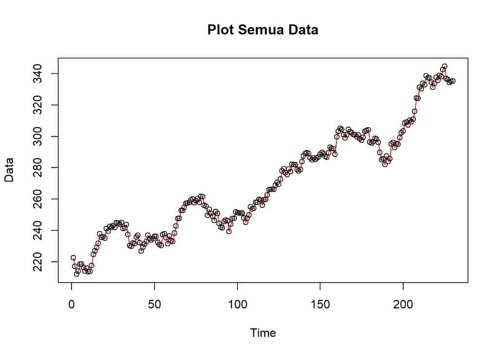

```r
# data full
ts.plot(data.ts, col="red",main="Plot Semua Data", type="o",xlab="Time",ylab="Data")
points(data.ts)
```

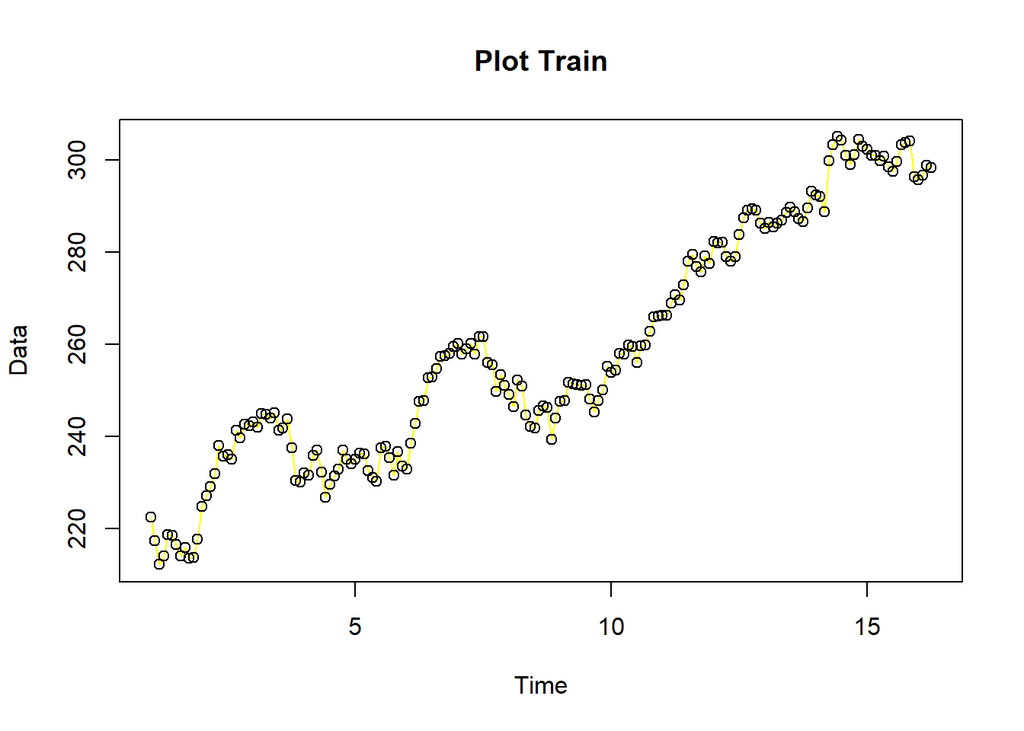

```r
# data latih
ts.plot(train.ts, col="yellow",main="Plot Train", type="o",xlab="Time",ylab="Data")
points(train.ts)
```

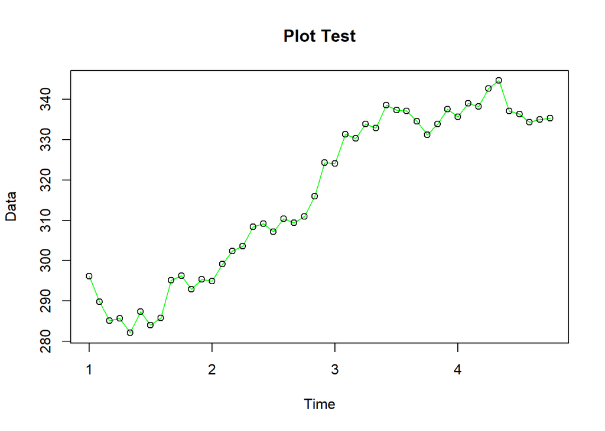

```r
# data uji
ts.plot(test.ts, col="green",main="Plot Test", type="o",xlab="Time",ylab="Data")
points(test.ts)
```

Dapat dilihat bahwa data deret waktu membentuk pola trend dan data tersebut tidak stasioner dalam rataan dan ragam.

# Check Stasioner

## Plot acf

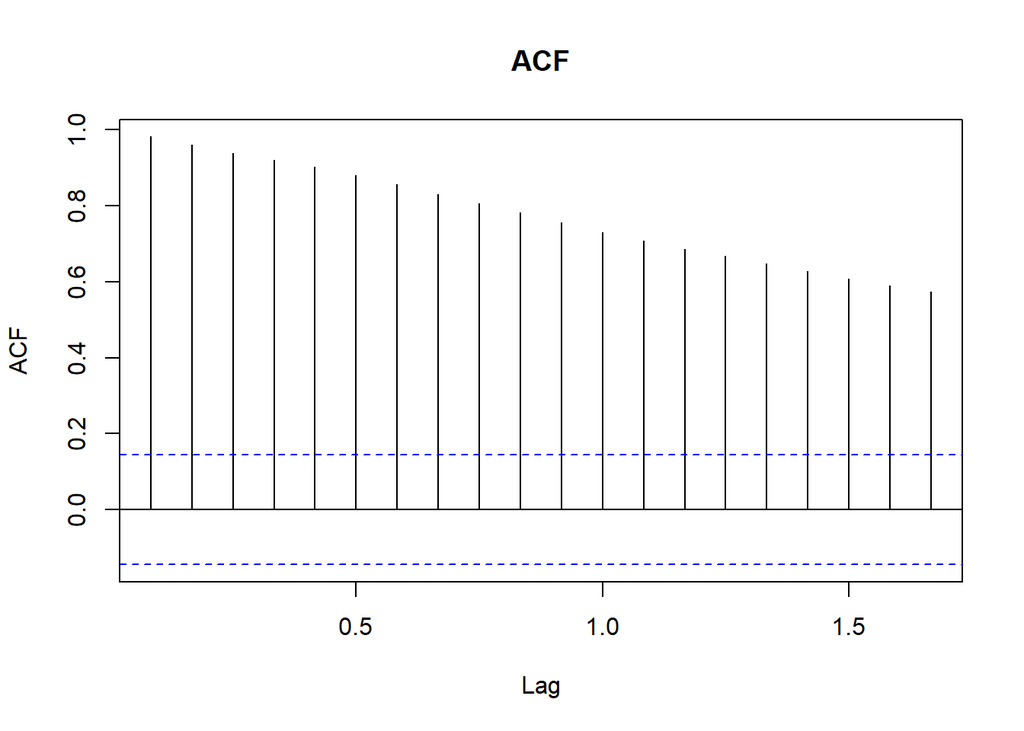

```r
acf(train.ts, main="ACF", lag.max=20)
```

Berdasarkan plot ACF pada data train, terlihat bahwa plot ACF pada data train menurun secara perlahan (*tails off slowly*) menandakan bahwa data train tersebut tidak stasioner dalam rataan.

## Uji ADF

```r
tseries::adf.test(train.ts)
```

```
##
##  Augmented Dickey-Fuller Test
##
## data:  train.ts
## Dickey-Fuller = -2.2068, Lag order = 5, p-value = 0.4897
## alternative hypothesis: stationary
```

$H_0$ : Data tidak stasioner dalam rataan

$H_1$ : Data stasioner dalam rataan

Berdasarkan uji ADF tersebut, didapat *p-value* sebesar 0.4897 yang lebih besar dari taraf nyata 5% sehingga tak tolak $H_0$ dan menandakan bahwa data tidak stasioner dalam rataan. Hal ini sesuai dengan hasil eksplorasi menggunakan plot time series dan plot ACF.

## Plot Box-Cox

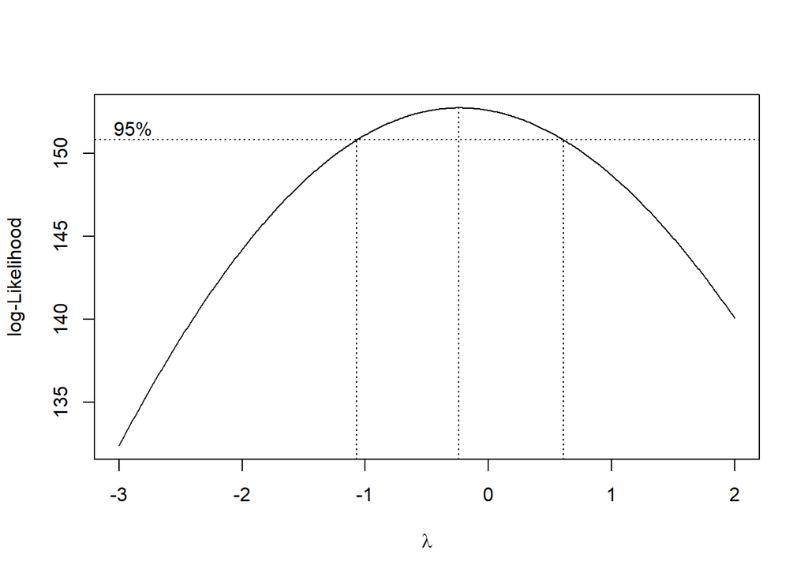

```r
index <- seq(1:184) #sebanyak row data
bc = boxcox(train.ts~index, lambda = seq(-3,2,by=0.01))
```

```r
#Nilai Rounded Lambda
lambda <- bc$x[which.max(bc$y)]
lambda
```

```
## [1] -0.24
```

```r
#SK
bc$x[bc$y > max(bc$y) - 1/2 * qchisq(.95,1)]
```

```
##   [1] -1.06 -1.05 -1.04 -1.03 -1.02 -1.01 -1.00 -0.99 -0.98 -0.97 -0.96 -0.95
##  [13] -0.94 -0.93 -0.92 -0.91 -0.90 -0.89 -0.88 -0.87 -0.86 -0.85 -0.84 -0.83
##  [25] -0.82 -0.81 -0.80 -0.79 -0.78 -0.77 -0.76 -0.75 -0.74 -0.73 -0.72 -0.71
##  [37] -0.70 -0.69 -0.68 -0.67 -0.66 -0.65 -0.64 -0.63 -0.62 -0.61 -0.60 -0.59
##  [49] -0.58 -0.57 -0.56 -0.55 -0.54 -0.53 -0.52 -0.51 -0.50 -0.49 -0.48 -0.47
##  [61] -0.46 -0.45 -0.44 -0.43 -0.42 -0.41 -0.40 -0.39 -0.38 -0.37 -0.36 -0.35
##  [73] -0.34 -0.33 -0.32 -0.31 -0.30 -0.29 -0.28 -0.27 -0.26 -0.25 -0.24 -0.23
##  [85] -0.22 -0.21 -0.20 -0.19 -0.18 -0.17 -0.16 -0.15 -0.14 -0.13 -0.12 -0.11
##  [97] -0.10 -0.09 -0.08 -0.07 -0.06 -0.05 -0.04 -0.03 -0.02 -0.01  0.00  0.01
## [109]  0.02  0.03  0.04  0.05  0.06  0.07  0.08  0.09  0.10  0.11  0.12  0.13
## [121]  0.14  0.15  0.16  0.17  0.18  0.19  0.20  0.21  0.22  0.23  0.24  0.25
## [133]  0.26  0.27  0.28  0.29  0.30  0.31  0.32  0.33  0.34  0.35  0.36  0.37
## [145]  0.38  0.39  0.40  0.41  0.42  0.43  0.44  0.45  0.46  0.47  0.48  0.49
## [157]  0.50  0.51  0.52  0.53  0.54  0.55  0.56  0.57  0.58  0.59  0.60
```

Gambar di atas menunjukkan nilai *rounded value* ($\lambda$) optimum sebesar **-0.24** dan pada selang kepercayaan 95% nilai memiliki batas bawah **-1.06** dan batas atas **0.60**. Selang tersebut tidak memuat nilai 1 sehingga dapat dikatakan bahwa data tersebut **tidak stasioner dalam rataan dan ragam**.

# Penanganan Data Tidak Stasioner dalam Rataan

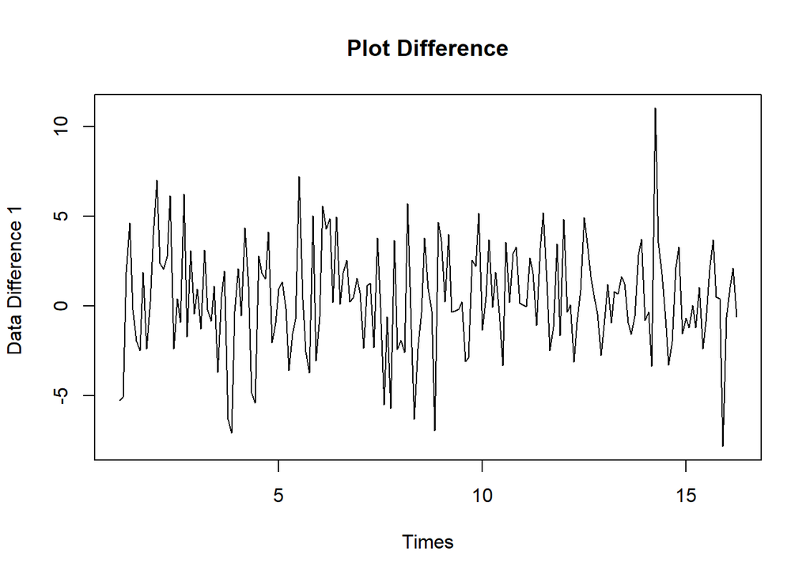

```r
train.diff<-diff(train.ts,differences = 1)
plot.ts(train.diff, lty=1, xlab="Times", ylab="Data Difference 1 ", main="Plot Difference")
```

Terlihat pada plot tersebut data sudah stasioner dalam rataan ditandai dengan data bergerak pada nilai tengah.

## Plot ACF dan PACF Setelah Penanganan

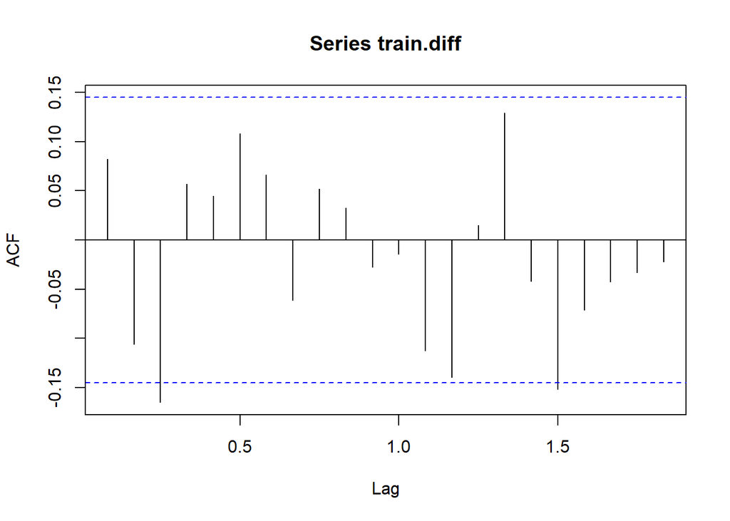

```r
acf_trainbaru <-acf(train.diff)
```

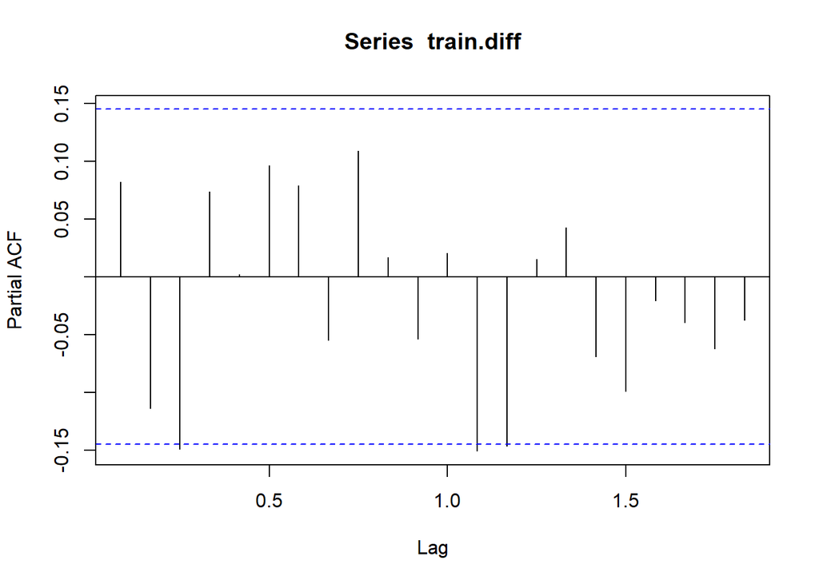

```r
pacf_trainbaru <- pacf(train.diff)
```

## Uji ADF

```r
tseries::adf.test(train.diff)
```

```
##
##  Augmented Dickey-Fuller Test
##
## data:  train.diff
## Dickey-Fuller = -4.9878, Lag order = 5, p-value = 0.01
## alternative hypothesis: stationary
```

$H_0$ : Data tidak stasioner dalam rataan

$H_1$ : Data stasioner dalam rataan

Berdasarkan uji ADF tersebut, didapat *p-value* sebesar 0.01 yang lebih kecil dari taraf nyata 5% sehingga tolak $H_0$ atau data stasioner dalam rataan. Sehingga dalam hal ini ketidakstasioneran data sudah berhasil ditangani dan dapat dilanjutkan ke pemodelan.

## Plot EACF

```r
eacf(train.diff)
```

```
## AR/MA
##   0 1 2 3 4 5 6 7 8 9 10 11 12 13
## 0 o o x o o o o o o o o  o  o  o
## 1 x o x o o o o o o o o  o  o  o
## 2 x x o o o o o o o o o  o  o  o
## 3 x x x o o o o o o o o  o  o  o
## 4 o o o x o o o o o o o  o  o  o
## 5 o x o x x o o o o o o  o  o  o
## 6 x x x o o x o o o o o  o  o  o
## 7 x x x x o x o o o o o  o  o  o
```

Identifikasi model menggunakan plot EACF dilakukan dengan melihat ujung segitiga pada pola segitiga nol. Dalam hal ini model tentatif yang terbentuk adalah ARIMA(0,1,3) atau MA(3), ARIMA(1,1,3) atau ARMA(1,3), dan ARIMA(2,1,2) atau ARMA(2,2).

# Pendugaan Parameter Model Tentatif

## ARIMA(0,1,3) atau MA(3)

```r
model1.da = Arima(train.diff,order=c(0,1,3),method = "ML")
summary(model1.da)
```

```
## Series: train.diff
## ARIMA(0,1,3)
##
## Coefficients:
##           ma1      ma2     ma3
##       -0.9275  -0.1413  0.0688
## s.e.   0.0815   0.0847  0.0756
##
## sigma^2 = 8.933:  log likelihood = -458.61
## AIC=925.21   AICc=925.44   BIC=938.03
##
## Training set error measures:
##                     ME     RMSE      MAE      MPE     MAPE      MASE     ACF1
## Training set 0.1444712 2.955898 2.249287 98.65469 141.1023 0.6748571 0.017177
```

```r
coeftest(model1.da)
```

```
##
## z test of coefficients:
##
##      Estimate Std. Error  z value Pr(>|z|)
## ma1 -0.927488   0.081525 -11.3768  < 2e-16 ***
## ma2 -0.141315   0.084727  -1.6679  0.09534 .
## ma3  0.068803   0.075576   0.9104  0.36262
## ---
## Signif. codes:  0 '***' 0.001 '**' 0.01 '*' 0.05 '.' 0.1 ' ' 1
```

Pada ARIMA(0,1,3) didapatkan nilai AIC sebesar 925.21 dan 1 dari 3 parameter signifikan.

## ARIMA(1,1,3) atau ARMA(1,3)

```r
model2.da = Arima(train.diff,order=c(1,1,3),method = "ML")
summary(model2.da)
```

```
## Series: train.diff
## ARIMA(1,1,3)
##
## Coefficients:
##           ar1      ma1      ma2      ma3
##       -0.7531  -0.1192  -0.7436  -0.1372
## s.e.   0.2846   0.2803   0.2678   0.0915
##
## sigma^2 = 9.002:  log likelihood = -458.68
## AIC=927.35   AICc=927.69   BIC=943.37
##
## Training set error measures:
##                     ME    RMSE      MAE      MPE     MAPE      MASE       ACF1
## Training set 0.1496358 2.95912 2.252053 86.66459 149.3025 0.6756869 -0.0143221
```

```r
coeftest(model2.da)
```

```
##
## z test of coefficients:
##
##     Estimate Std. Error z value Pr(>|z|)
## ar1 -0.75313    0.28456 -2.6467 0.008129 **
## ma1 -0.11918    0.28028 -0.4252 0.670673
## ma2 -0.74363    0.26778 -2.7770 0.005486 **
## ma3 -0.13719    0.09145 -1.5001 0.133577
## ---
## Signif. codes:  0 '***' 0.001 '**' 0.01 '*' 0.05 '.' 0.1 ' ' 1
```

Pada ARIMA(1,1,3) didapatkan nilai AIC sebesar 927.35 dan 2 dari 4 parameter signifikan.

## ARIMA(2,1,2) atau ARMA(2,2)

```r
model3.da = Arima(train.diff,order=c(2,1,2),method = "ML")
summary(model3.da)
```

```
## Series: train.diff
## ARIMA(2,1,2)
##
## Coefficients:
##          ar1      ar2      ma1     ma2
##       0.4489  -0.1624  -1.3591  0.3591
## s.e.  0.2569   0.0745   0.2530  0.2526
##
## sigma^2 = 8.852:  log likelihood = -457.4
## AIC=924.8   AICc=925.14   BIC=940.82
##
## Training set error measures:
##                     ME     RMSE      MAE      MPE     MAPE     MASE
## Training set 0.1317738 2.934323 2.218014 98.94114 144.5761 0.665474
##                      ACF1
## Training set -0.004304564
```

```r
coeftest(model3.da)
```

```
##
## z test of coefficients:
##
##      Estimate Std. Error z value  Pr(>|z|)
## ar1  0.448873   0.256870  1.7475   0.08056 .
## ar2 -0.162426   0.074528 -2.1794   0.02930 *
## ma1 -1.359114   0.253044 -5.3711 7.828e-08 ***
## ma2  0.359114   0.252555  1.4219   0.15505
## ---
## Signif. codes:  0 '***' 0.001 '**' 0.01 '*' 0.05 '.' 0.1 ' ' 1
```

Pada ARIMA(2,1,2) didapatkan nilai AIC sebesar 924.8 dan 2 dari 4 parameter signifikan.

## ARIMA(2,1,3) atau ARMA(2,3)

```r
model4.da = Arima(train.diff,order=c(2,1,3),method = "ML")
summary(model4.da)
```

```
## Series: train.diff
## ARIMA(2,1,3)
##
## Coefficients:
##           ar1      ar2     ma1      ma2      ma3
##       -1.1005  -0.8807  0.2221  -0.2221  -1.0000
## s.e.   0.0390   0.0387  0.0327   0.0288   0.0434
##
## sigma^2 = 8.434:  log likelihood = -454.37
## AIC=920.74   AICc=921.22   BIC=939.97
##
## Training set error measures:
##                     ME     RMSE      MAE      MPE     MAPE      MASE       ACF1
## Training set 0.1431071 2.856047 2.174867 82.63712 156.1269 0.6525286 0.02004346
```

```r
coeftest(model4.da)
```

```
##
## z test of coefficients:
##
##      Estimate Std. Error  z value  Pr(>|z|)
## ar1 -1.100513   0.039041 -28.1885 < 2.2e-16 ***
## ar2 -0.880662   0.038701 -22.7555 < 2.2e-16 ***
## ma1  0.222058   0.032694   6.7920 1.106e-11 ***
## ma2 -0.222057   0.028750  -7.7237 1.130e-14 ***
## ma3 -0.999999   0.043432 -23.0243 < 2.2e-16 ***
## ---
## Signif. codes:  0 '***' 0.001 '**' 0.01 '*' 0.05 '.' 0.1 ' ' 1
```

Pada ARIMA(2,1,3) didapatkan nilai AIC sebesar 920.74 dan semua parameter signifikan.

Berdasarkan pendugaan parameter di atas, nilai AIC terkecil dimiliki oleh model ARIMA(2,1,3) dan parameter model ARIMA(2,1,3) juga seluruhnya signifikan sehingga model yang dipilih adalah model ARIMA(2,1,3).

# Analisis Sisaan

Model terbaik hasil identifikasi kemudian dicek asumsi sisaannya. Sisaan model ARIMA harus memenuhi asumsi normalitas, kebebasan sisaan, dan kehomogenan ragam. Diagnostik model dilakukan secara eksplorasi dan uji formal.

## Eksplorasi

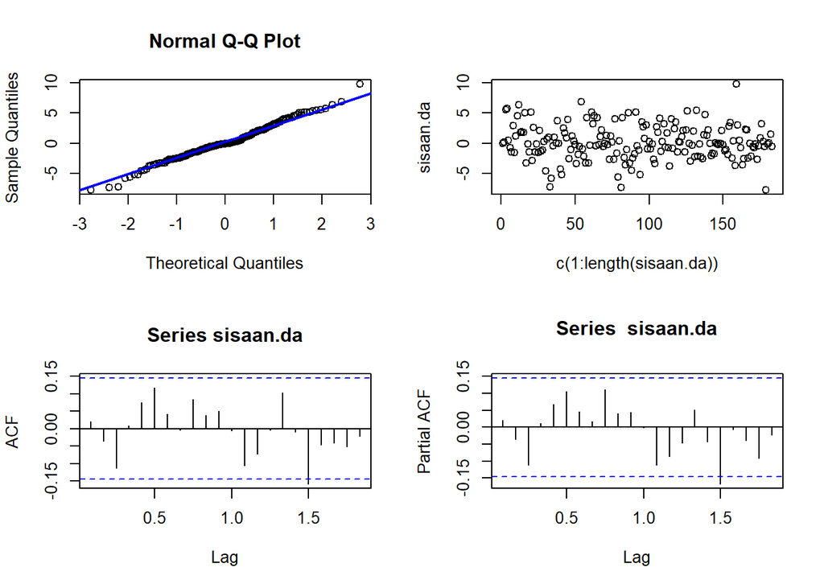

```r
#Eksplorasi
sisaan.da <- model4.da$residuals
par(mfrow=c(2,2))
qqnorm(sisaan.da)
qqline(sisaan.da, col = "blue", lwd = 2)
plot(c(1:length(sisaan.da)),sisaan.da)
acf(sisaan.da)
pacf(sisaan.da)
```

```r
par(mfrow = c(1,1))
```

# Uji Formal

```r
#1) Sisaan Menyebar Normal
ks.test(sisaan.da,"pnorm")
```

```
##
##  Asymptotic one-sample Kolmogorov-Smirnov test
##
## data:  sisaan.da
## D = 0.24565, p-value = 5.123e-10
## alternative hypothesis: two-sided
```

$H_0$ : Sisaan menyebar normal

$H_1$ : Sisaan tidak menyebar normal

```r
#2) Sisaan saling bebas/tidak ada autokorelasi
Box.test(sisaan.da, type = "Ljung")
```

```
##
##  Box-Ljung test
##
## data:  sisaan.da
## X-squared = 0.07473, df = 1, p-value = 0.7846
```

$H_0$ : Sisaan saling bebas

$H_1$ : Sisaan tidak tidak saling bebas

Berdasarkan uji Ljung-Box tersebut, didapat *p-value* sebesar 0.7846 yang lebih besar dari taraf nyata 5% sehingga tak tolak $H_0$ dan menandakan bahwa sisaan saling bebas. Artinya tidak ada autokorelasi.

```r
#3) Sisaan homogen
Box.test((sisaan.da)^2, type = "Ljung")
```

```
##
##  Box-Ljung test
##
## data:  (sisaan.da)^2
## X-squared = 0.15027, df = 1, p-value = 0.6983
```

$H_0$ : Ragam sisaan homogen

$H_1$ : Ragam sisaan tidak homogen

Berdasarkan uji Ljung-Box tersebut. didapat *p-value* sebesar 0.6983 yang lebih besar dari taraf nyata 5% sehingga tak tolak $H_0$ dan menandakan bahwa ragam sisaan homogen.

```r
#4) Nilai tengah sisaan sama dengan nol
t.test(sisaan.da, mu = 0, conf.level = 0.95)  #tak tolak h0 > nilai tengah sisaan sama dengan 0
```

```
##
##  One Sample t-test
##
## data:  sisaan.da
## t = 0.67683, df = 182, p-value = 0.4994
## alternative hypothesis: true mean is not equal to 0
## 95 percent confidence interval:
##  -0.2740785  0.5602928
## sample estimates:
## mean of x
## 0.1431071
```

$H_0$ : nilai tengah sisaan sama dengan 0

$H_1$ : nilai tengah sisaan tidak sama dengan 0

Berdasarkan uji-t tersebut, didapat *p-value* sebesar 0.4994 yang lebih besar dari taraf nyata 5% sehingga tak tolak $H_0$ dan menandakan bahwa nilai tengah sisaan sama dengan 0.

# Overfitting

## ARIMA(3,1,3) atau ARMA(3,3)

```r
model5=Arima(train.ts, order=c(3,1,3),method="ML")
summary(model5)
```

```
## Series: train.ts
## ARIMA(3,1,3)
##
## Coefficients:
```

```
##           ar1      ar2      ar3     ma1     ma2     ma3
##       -0.3054  -0.1499  -0.2905  0.4084  0.1132  0.1231
## s.e.   0.0331   0.2572      NaN     NaN  0.2742     NaN
##
## sigma^2 = 8.937:  log likelihood = -457.07
## AIC=928.15   AICc=928.79   BIC=950.61
##
## Training set error measures:
##                     ME     RMSE      MAE       MPE      MAPE      MASE
## Training set 0.4357499 2.932123 2.225626 0.1615452 0.8801785 0.2263554
##                     ACF1
## Training set -0.01788524
```

```r
lmtest::coeftest(model5)
```

```
##
## z test of coefficients:
##
##      Estimate Std. Error z value Pr(>|z|)
## ar1 -0.305432   0.033083 -9.2322   <2e-16 ***
## ar2 -0.149886   0.257170 -0.5828   0.5600
## ar3 -0.290455        NaN     NaN      NaN
## ma1  0.408407        NaN     NaN      NaN
## ma2  0.113245   0.274154  0.4131   0.6796
## ma3  0.123144        NaN     NaN      NaN
## ---
## Signif. codes:  0 '***' 0.001 '**' 0.01 '*' 0.05 '.' 0.1 ' ' 1
```

Berdasarkan hasil overfitting yg terbaik tetap model ARIMA(2,1,3) atau ARMA(2,3).

# Peramalan

```r
#---FORECAST---#
ramalan <- forecast::forecast(model4.da, h = length(test))
ramalan
```

```
##        Point Forecast     Lo 80    Hi 80     Lo 95    Hi 95
## May 16      0.9148517 -2.834974 4.664678 -4.820012 6.649716
## Jun 16      0.2698652 -3.507071 4.046802 -5.506461 6.046191
## Jul 16      0.1358755 -3.641224 3.912975 -5.640700 5.912451
## Aug 16      0.8513479 -2.936652 4.639347 -4.941897 6.644593
## Sep 16      0.1819609 -3.628886 3.992808 -5.646226 6.010148
## Oct 16      0.2885407 -3.524963 4.102044 -5.543710 6.120791
## Nov 16      0.7607518 -3.055554 4.577057 -5.075784 6.597287
## Dec 16      0.1472167 -3.685073 3.979507 -5.713765 6.008198
## Jan 17      0.4065617 -3.430608 4.243731 -5.461883 6.275006
## Feb 17      0.6614661 -3.175812 4.498744 -5.207145 6.530077
## Mar 17      0.1525453 -3.694080 3.999170 -5.730360 6.035451
## Apr 17      0.4881346 -3.363934 4.340204 -5.403096 6.379366
## May 17      0.5670014 -3.285368 4.419371 -5.324690 6.458693
## Jun 17      0.1846668 -3.672143 4.041477 -5.713815 6.083148
## Jul 17      0.5359760 -3.325400 4.397352 -5.369490 6.441442
## Aug 17      0.4860632 -3.376696 4.348822 -5.421517 6.393643
## Sep 17      0.2316083 -3.632708 4.095924 -5.678353 6.141570
## Oct 17      0.5555955 -3.311760 4.422951 -5.359014 6.470205
## Nov 17      0.4231321 -3.446448 4.292712 -5.494880 6.341144
## Dec 17      0.2835866 -3.586267 4.153440 -5.634843 6.202017
## Jan 18      0.5538136 -3.317617 4.425244 -5.367029 6.474656
## Feb 18      0.3793177 -3.494569 4.253204 -5.545280 6.303915
## Mar 18      0.3333741 -3.540452 4.207200 -5.591131 6.257879
## Apr 18      0.5376075 -3.336783 4.411998 -5.387762 6.462977
## May 18      0.3533068 -3.523247 4.229860 -5.575370 6.281983
## Jun 18      0.3762716 -3.500284 4.252827 -5.552408 6.304951
## Jul 18      0.5133052 -3.363316 4.389927 -5.415476 6.442086
## Aug 18      0.3422737 -3.535952 4.220499 -5.588960 6.273507
## Sep 18      0.4098158 -3.468533 4.288164 -5.521606 6.341238
## Oct 18      0.4861057 -3.392196 4.364408 -5.445245 6.417457
## Nov 18      0.3426659 -3.536654 4.221986 -5.590243 6.275575
## Dec 18      0.4333376 -3.446150 4.312826 -5.499827 6.366503
## Jan 19      0.4598742 -3.419657 4.339405 -5.473357 6.393105
## Feb 19      0.3508193 -3.529260 4.230898 -5.583250 6.284888
## Mar 19      0.4474659 -3.432742 4.327674 -5.486801 6.381732
## Apr 19      0.4371456 -3.443244 4.317535 -5.497398 6.371689
## May 19      0.3633902 -3.517236 4.244016 -5.571515 6.298296
## Jun 19      0.4536476 -3.427032 4.334327 -5.481339 6.388634
## Jul 19      0.4192717 -3.461688 4.300231 -5.516143 6.354687
## Aug 19      0.3776166 -3.503406 4.258639 -5.557895 6.313129
## Sep 19      0.4537321 -3.427276 4.334741 -5.481758 6.389223
## Oct 19      0.4066501 -3.474670 4.287970 -5.529316 6.342617
## Nov 19      0.3914324 -3.489871 4.272736 -5.544509 6.327374
## Dec 19      0.4496430 -3.431612 4.330898 -5.486225 6.385511
## Jan 20      0.3989831 -3.482557 4.280523 -5.537320 6.335287
## Feb 20      0.4034712 -3.478024 4.284966 -5.532763 6.339706
```

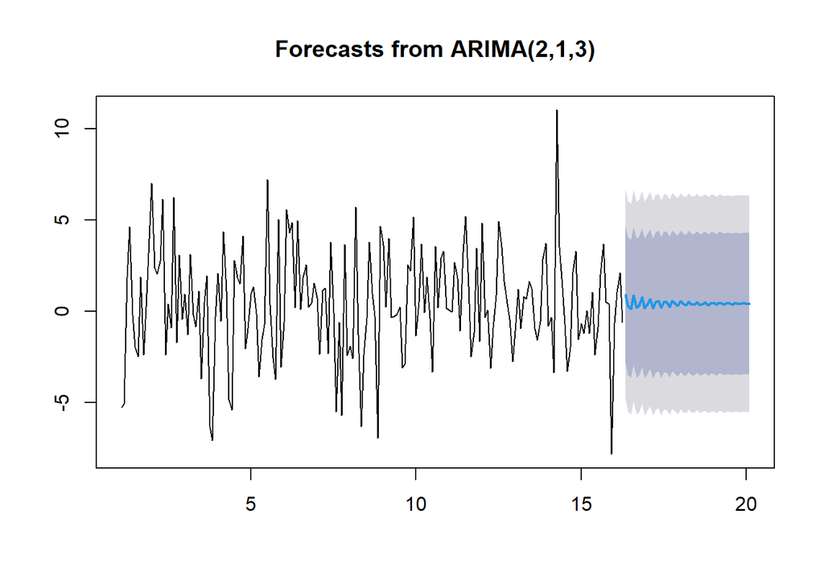

```r
data.ramalan <- ramalan$mean
plot(ramalan)
```

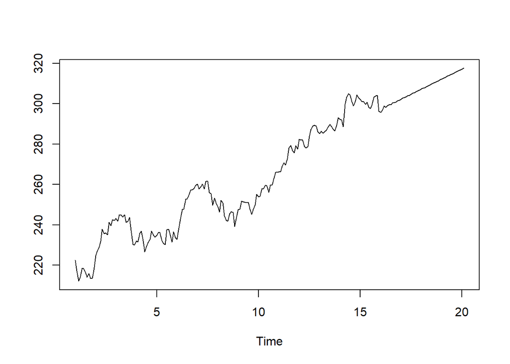

```r
pt_1 <- train.ts[184] #nilai akhir data latih
hasil.forc.Diff <- data.ramalan
hasil <- diffinv(hasil.forc.Diff, differences = 1) + pt_1
#has.1 sama hasilnta dengan: cumsum(c(pt_1,hasil.forc.Diff))
ts.plot(train.ts,hasil)
```

# AKURASI

```r
perbandingan <- matrix(data=c(head(test.ts, n=length(test)), hasil[-1]),
                     nrow = length(test), ncol = 2)
colnames(perbandingan) <- c("Aktual","Hasil Forecast")
perbandingan
```

```
##       Aktual Hasil Forecast
##  [1,] 296.14       299.1449
##  [2,] 289.80       299.4147
##  [3,] 285.10       299.5506
##  [4,] 285.71       300.4020
##  [5,] 282.12       300.5839
##  [6,] 287.40       300.8725
##  [7,] 284.05       301.6332
##  [8,] 285.78       301.7804
##  [9,] 295.18       302.1870
## [10,] 296.22       302.8484
## [11,] 292.92       303.0010
## [12,] 295.34       303.4891
## [13,] 294.91       304.0561
## [14,] 299.21       304.2408
```

[output cut: 32 more lines]

```r
accuracy(hasil[-1], head(test.ts, n=length(test)))
```

```
##               ME     RMSE      MAE      MPE     MAPE      ACF1 Theil's U
## Test set 8.05712 17.11779 14.90296 2.247414 4.617991 0.9610331  4.387415
```